# 꿈꾸는 데이터 디자이너 2기 - 01 Rbasic

Mino

Sunday, August 23, 2015

# data type

## 숫자

```r
10
```

```
## [1] 10
```

```r
10.0
```

```
## [1] 10
```

## 문자

```r
'10'
```

```
## [1] "10"
```

```r
'a'
```

```
## [1] "a"
```

```r
'안뇽'
```

```
## [1] "안뇽"
```

## logical(True/False)

```r
TRUE
```

```
## [1] TRUE
```

```r
FALSE
```

```
## [1] FALSE
```

```r
T
```

```
## [1] TRUE
```

```r
F
```

```
## [1] FALSE
```

```r
0
```

```
## [1] 0
```

```r
1
```

```
## [1] 1
```

```r
TRUE + TRUE # = ????
```

```
## [1] 2
```

## factor

- 범주형 자료에 대한 표현

#### 명목형 Nominal

```r
factor(c('x','x','x','y','y'))
```

```
## [1] x x x y y
## Levels: x y
```

```r
iris$Species
```

```
##   [1] setosa     setosa     setosa     setosa     setosa     setosa
##   [7] setosa     setosa     setosa     setosa     setosa     setosa
##  [13] setosa     setosa     setosa     setosa     setosa     setosa
##  [19] setosa     setosa     setosa     setosa     setosa     setosa
##  [25] setosa     setosa     setosa     setosa     setosa     setosa
##  [31] setosa     setosa     setosa     setosa     setosa     setosa
##  [37] setosa     setosa     setosa     setosa     setosa     setosa
##  [43] setosa     setosa     setosa     setosa     setosa     setosa
##  [49] setosa     setosa     versicolor versicolor versicolor versicolor
##  [55] versicolor versicolor versicolor versicolor versicolor versicolor
##  [61] versicolor versicolor versicolor versicolor versicolor versicolor
##  [67] versicolor versicolor versicolor versicolor versicolor versicolor
##  [73] versicolor versicolor versicolor versicolor versicolor versicolor
##  [79] versicolor versicolor versicolor versicolor versicolor versicolor
##  [85] versicolor versicolor versicolor versicolor versicolor versicolor
##  [91] versicolor versicolor versicolor versicolor versicolor versicolor
##  [97] versicolor versicolor versicolor versicolor virginica  virginica
## [103] virginica  virginica  virginica  virginica  virginica  virginica
## [109] virginica  virginica  virginica  virginica  virginica  virginica
## [115] virginica  virginica  virginica  virginica  virginica  virginica
## [121] virginica  virginica  virginica  virginica  virginica  virginica
## [127] virginica  virginica  virginica  virginica  virginica  virginica
## [133] virginica  virginica  virginica  virginica  virginica  virginica
## [139] virginica  virginica  virginica  virginica  virginica  virginica
## [145] virginica  virginica  virginica  virginica  virginica  virginica
## Levels: setosa versicolor virginica
```

```r
table(iris$Species)
```

```
##
##     setosa versicolor  virginica
##         50         50         50
```

#### 순서형 Ordinal

```r
factor(c('x','x','x','y','y'), ordered = TRUE)
```

```
## [1] x x x y y
## Levels: x < y
```

```r
ordered(c('x','x','x','y','y'))
```

```
## [1] x x x y y
## Levels: x < y
```

```r
ordered(c('x','x','x','y','y'), levels = c('y', 'x'))
```

```
## [1] x x x y y
## Levels: y < x
```

# Data Structure

## Vector 벡터

- 동일한 타입의 데이터를 한 개 이상 저장해둔 형태(한 개도 됩니다!)

### 벡터 - 숫자

```r
1:10
```

```
##  [1]  1  2  3  4  5  6  7  8  9 10
```

```r
c(1.1, 1.2, 1.3)
```

```
## [1] 1.1 1.2 1.3
```

### 벡터 - 문자

```r
month.name
```

```
##  [1] "January"   "February"  "March"     "April"     "May"
##  [6] "June"      "July"      "August"    "September" "October"
## [11] "November"  "December"
```

```r
str(month.name)
```

```
##  chr [1:12] "January" "February" "March" "April" "May" ...
```

#### 벡터 만들기 : c()

```r
new_vector = c(1,2,3,4,5)
new_vector
```

```
## [1] 1 2 3 4 5
```

#### 원하는 항목만 선택하기(인덱스는 1부터 시작)

- n이라는 숫자가 들어가면, n번째 항목을 불러온다
- 음수가 들어가면, 해당 항목을 제외하고 불러온다
- 숫자로 이루어진 벡터가 들어가면, 해당 숫자들에 해당하는 위치의 요소들을 불러온다
- 문자로 이루어진 벡터라면, 해당하는 이름의 요소들을 불러온다

```r
letters[1]
```

```
## [1] "a"
```

```r
letters[1:5]
```

```
## [1] "a" "b" "c" "d" "e"
```

```r
letters[c(1,3,5)]
```

```
## [1] "a" "c" "e"
```

```r
letters[-3]
```

```
##  [1] "a" "b" "d" "e" "f" "g" "h" "i" "j" "k" "l" "m" "n" "o" "p" "q" "r"
## [18] "s" "t" "u" "v" "w" "x" "y" "z"
```

#### 벡터 합치기

- 벡터는 중첩이 되지 않기 때문에 벡터 중간에 벡터가 들어가면 두 개의 벡터가 합쳐진 하나의 벡터가 나온다

```r
c(1,3,5,7,9, c(4,5,6))
```

```
## [1] 1 3 5 7 9 4 5 6
```

#### 벡터에 이름붙이기

`names()` 함수는 그냥 사용하면 벡터 내의 이름들을 보여준다

`names(---) = 벡터` 로 사용하면 오른쪽의 벡터로 이름을 지정한다

이름을 지정하고 나면 벡터의 이름으로도 호출이 가능하다

```r
score = c(100, 70, 90)
names(score) # NULL
```

```r
names(score) = c('Korean', 'Math', 'English')
names(score)
```

```
## [1] "Korean"  "Math"    "English"
```

```r
score
```

```
##  Korean    Math English
##     100      70      90
```

```r
score['Math']
```

```
## Math
##   70
```

#### 하나의 벡터에는 하나의 타입만 들어갈 수 있다

```r
num_vector = 1:10
  str(num_vector) # int(integer)
```

```
##  int [1:10] 1 2 3 4 5 6 7 8 9 10
```

```r
num_vector[5] = 'a'
  str(num_vector) # chr(character)
```

```
##  chr [1:10] "1" "2" "3" "4" "a" "6" "7" "8" "9" ...
```

#### 벡터 관련 함수들

```r
length(score)
```

```
## [1] 3
```

```r
seq(from = 1, to = 10, by = 2)
```

```
## [1] 1 3 5 7 9
```

```r
rep(x = c(1,3,5), times = 3)
```

```
## [1] 1 3 5 1 3 5 1 3 5
```

```r
rep(x = c(1,3,5), each = 3)
```

```
## [1] 1 1 1 3 3 3 5 5 5
```

```r
rep(x = c(1,3,5), times = 3, each = 3)
```

```
##  [1] 1 1 1 3 3 3 5 5 5 1 1 1 3 3 3 5 5 5 1 1 1 3 3 3 5 5 5
```

#### 그래프 그리기?

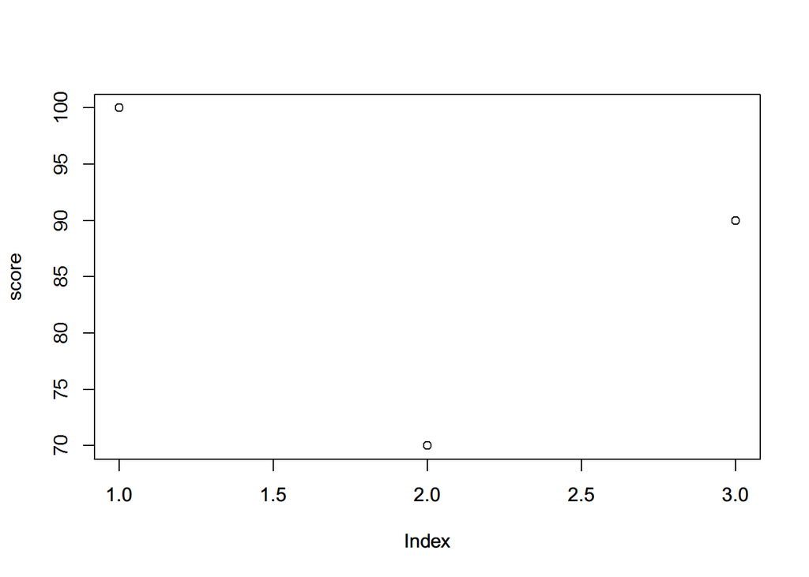

```r
plot(score)
```

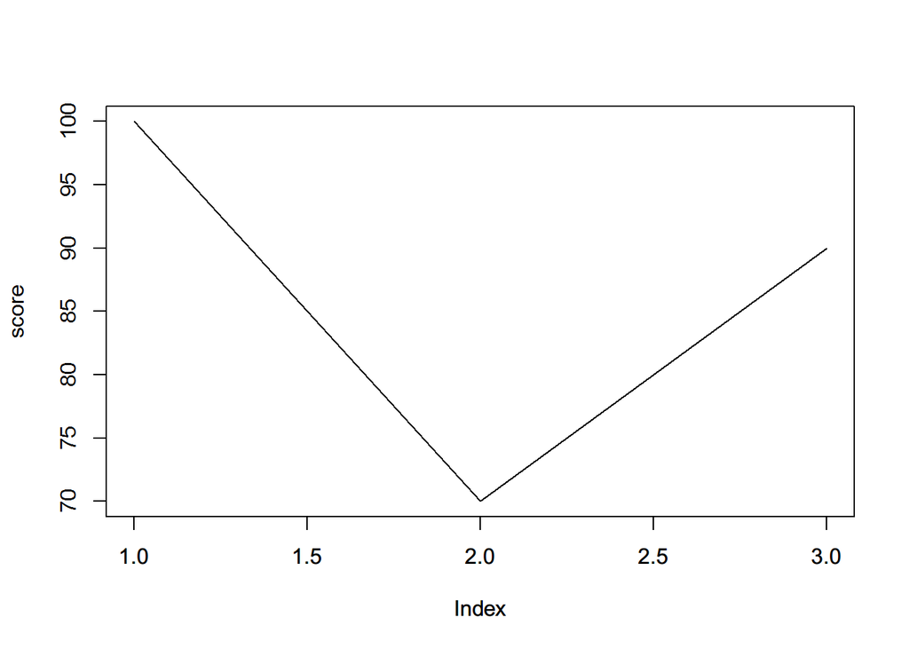

```r
plot(score, type='l')
```

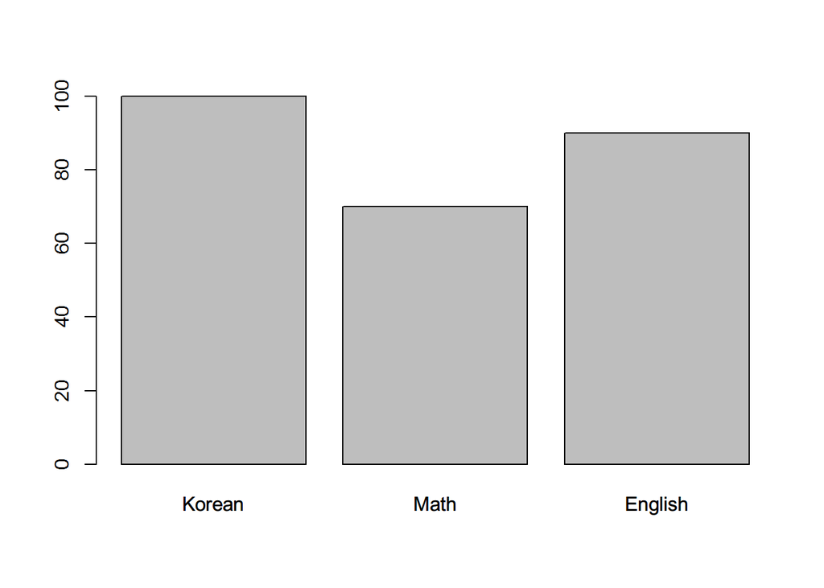

```r
barplot(score)
```

## Matrix 행렬

행과 열을 가지는 벡터

벡터와 마찬가지로 같은 유형의 타입만 적용할 수 있다. 숫자만 넣든가 문자만 넣든가.

```r
str(volcano) # num
```

```
##  num [1:87, 1:61] 100 101 102 103 104 105 105 106 107 108 ...
```

```r
class(volcano) # matrix
```

```
## [1] "matrix"
```

#### 행렬 만들기

```r
new_matrix = matrix(c(1:9), nrow = 3, ncol = 3) # 열 방향으로 들어간다
matrix(c(1:9), nrow = 3, ncol = 3, byrow = TRUE) # byrow 옵션을 TRUE로 해주면 행 방향으로 들어간다
```

```
##      [,1] [,2] [,3]
## [1,]    1    2    3
## [2,]    4    5    6
## [3,]    7    8    9
```

#### 실습?

```r
scores = matrix(c(70,80,90, 40,50,60, 50,95,70), nrow = 3, byrow = TRUE)
```

#### 데이터에 접근하기

행렬[행번호, 열번호]의 형태로 선택가능하다

가운데가 콤마가 꼭 들어가야 한다는 점을 제외하면 벡터와 비슷하다

```r
new_matrix[,3]
```

```
## [1] 7 8 9
```

```r
new_matrix[1,2]
```

```
## [1] 4
```

```r
new_matrix[3,c(1,2)]
```

```
## [1] 3 6
```

#### 행렬의 연산

```r
new_matrix + 10
```

```
##      [,1] [,2] [,3]
## [1,]   11   14   17
## [2,]   12   15   18
## [3,]   13   16   19
```

```r
new_matrix * 5
```

```
##      [,1] [,2] [,3]
## [1,]    5   20   35
## [2,]   10   25   40
## [3,]   15   30   45
```

```r
new_matrix + scores
```

```
##      [,1] [,2] [,3]
## [1,]   71   84   97
## [2,]   42   55   68
## [3,]   53  101   79
```

```r
new_matrix * scores # 같은 위치끼리 곱하기
```

```
##      [,1] [,2] [,3]
## [1,]   70  320  630
## [2,]   80  250  480
## [3,]  150  570  630
```

```r
new_matrix %*% scores # 행렬곱
```

```
##      [,1] [,2] [,3]
## [1,]  580  945  820
## [2,]  740 1170 1040
## [3,]  900 1395 1260
```

#### 행렬 관련 함수들

```r
dim(new_matrix) # 해당 행렬의 차원을 행, 열 로 알려준다
```

```
## [1] 3 3
```

```r
t(new_matrix) # 전치행렬(행과 열을 뒤바꾼 행렬)을 구한다
```

```
##      [,1] [,2] [,3]
## [1,]    1    2    3
## [2,]    4    5    6
## [3,]    7    8    9
```

#### 그래프 그리기

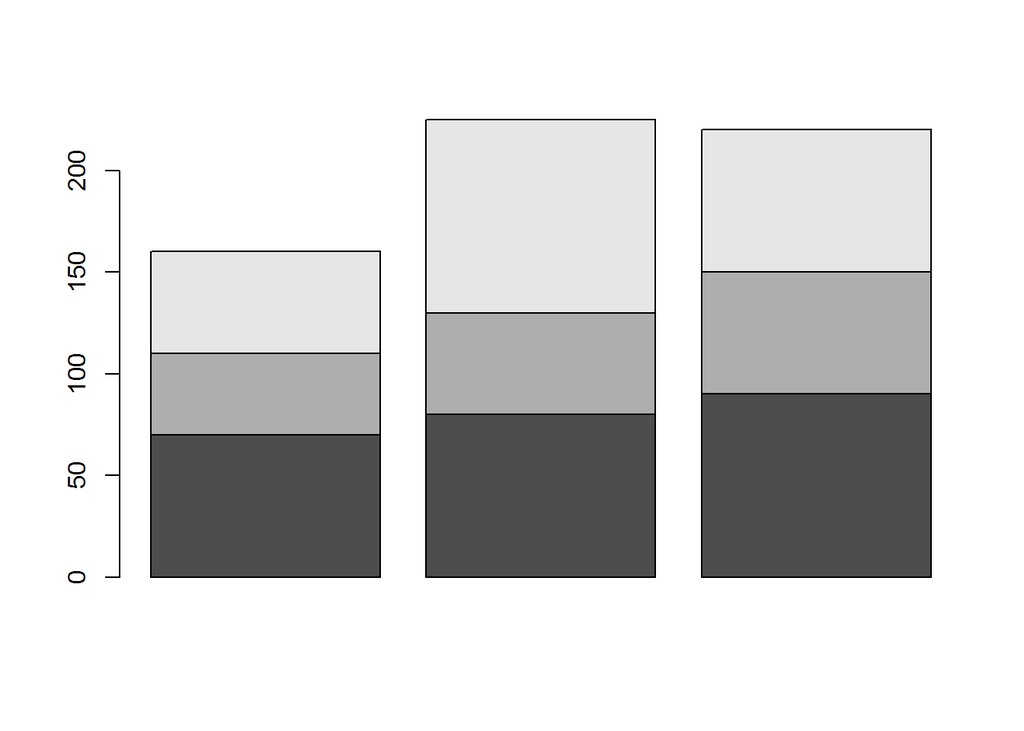

```r
barplot(scores)
```

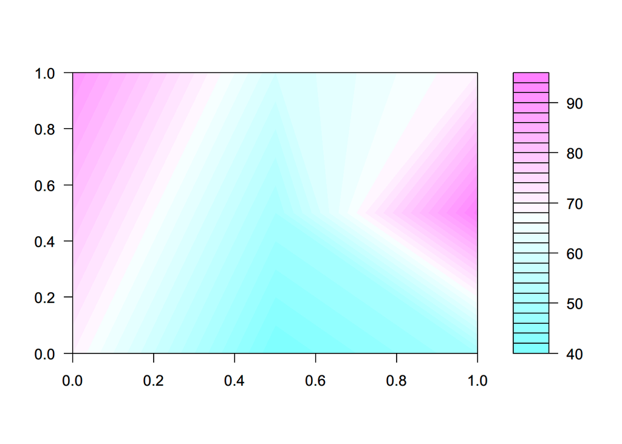

```r
filled.contour(scores)
```

## Array 배열

- 행렬이 2차원의 데이터인 반면 배열은 3차원 이상의 다차원 데이터를 말한다.
- 행, 열 이외에 추가적인 차원을 가진다는 점 말고는 행렬과 비슷하다

```r
class(Titanic[,,,1])
```

```
## [1] "array"
```

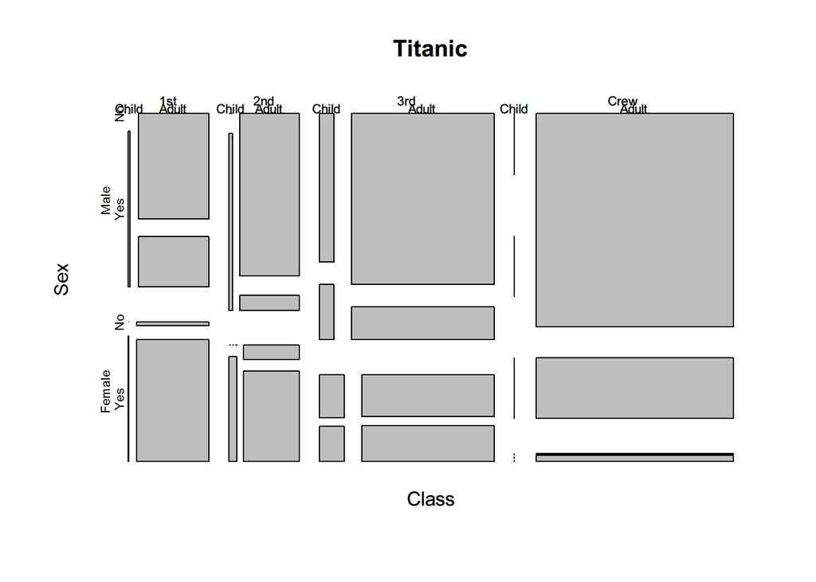

```r
plot(Titanic)
```

## List 리스트

- key: value 형태의 데이터
- 서로 다른 형태의 데이터를 담을 수 있다
- 각 key에 담겨있는 value는 타입이 다를 수도 있고 길이가 다를 수도 있다.

#### 리스트 만들기

```r
score_list = list(
  student01 = c(100,40,50),
  student02 = c(40, 50, 60, 70),
  student03 = c(50, 80, 30, 50, 60),
  test_list = list(test_name = c('A', 'B', 'C', 'D', 'E'),
                   test_date = c('20150801', '20150803', '20150805', '20150807', '20150809')
                   )
  )
```

#### 데이터에 접근하기

```r
score_list$student01
```

```
## [1] 100  40  50
```

```r
score_list$test_list
```

```
## $test_name
## [1] "A" "B" "C" "D" "E"
##
## $test_date
## [1] "20150801" "20150803" "20150805" "20150807" "20150809"
```

```r
score_list$test_list$test_date
```

```
## [1] "20150801" "20150803" "20150805" "20150807" "20150809"
```

```r
score_list[1] # key : value
```

```
## $student01
## [1] 100  40  50
```

```r
score_list[[1]] # value
```

```
## [1] 100  40  50
```

```r
score_list[[4]][[1]]
```

```
## [1] "A" "B" "C" "D" "E"
```

```r
score_list[[4]][1]
```

```
## $test_name
## [1] "A" "B" "C" "D" "E"
```

## data.frame 데이터 프레임

- 실질적으로는 가장 많이 사용하게 될 형태
- 데이터베이스나 스프레드시트와 유사한 형태를 가진다
- 행렬처럼 행과 열의 길이가 일정하지만 각 열마다 다른 형태의 자료를 담을 수 있다

```r
str(iris)
```

```
## 'data.frame':    150 obs. of  5 variables:
##  $ Sepal.Length: num  5.1 4.9 4.7 4.6 5 5.4 4.6 5 4.4 4.9 ...
##  $ Sepal.Width : num  3.5 3 3.2 3.1 3.6 3.9 3.4 3.4 2.9 3.1 ...
##  $ Petal.Length: num  1.4 1.4 1.3 1.5 1.4 1.7 1.4 1.5 1.4 1.5 ...
##  $ Petal.Width : num  0.2 0.2 0.2 0.2 0.2 0.4 0.3 0.2 0.2 0.1 ...
##  $ Species     : Factor w/ 3 levels "setosa","versicolor",..: 1 1 1 1 1 1 1 1 1 1 ...
```

#### 데이터 프레임 만들기

```r
score_df = data.frame(
  math = c(40, 70, 80),
  korean = c(50, 60, 70),
  english = c(30, 40, 50),
  art = c('A','A','C')
  )
```

#### 데이터에 접근하기

- 행렬과 비슷하게 접근할 수도 있고, 리스트처럼 $을 활용할수도 있다
- 아래 세 가지는 모두 동일!

```r
score_df$math
```

```
## [1] 40 70 80
```

```r
score_df[,1]
```

```
## [1] 40 70 80
```

```r
score_df[,'math']
```

```
## [1] 40 70 80
```

```r
score_df[,1:2]
```

```
##   math korean
## 1   40     50
## 2   70     60
## 3   80     70
```

```r
score_df[,c('math', 'korean')]
```

```
##   math korean
## 1   40     50
## 2   70     60
## 3   80     70
```

#### 그래프 그리기

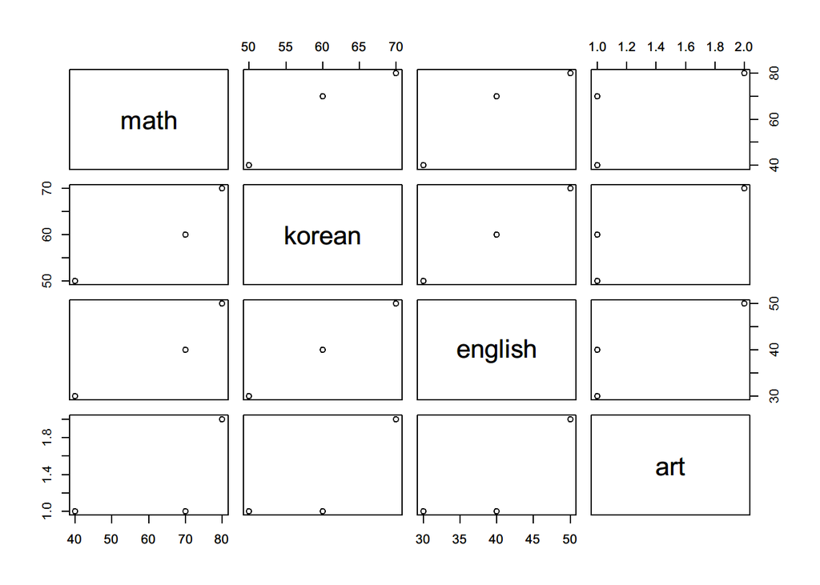

```r
plot(score_df)
```

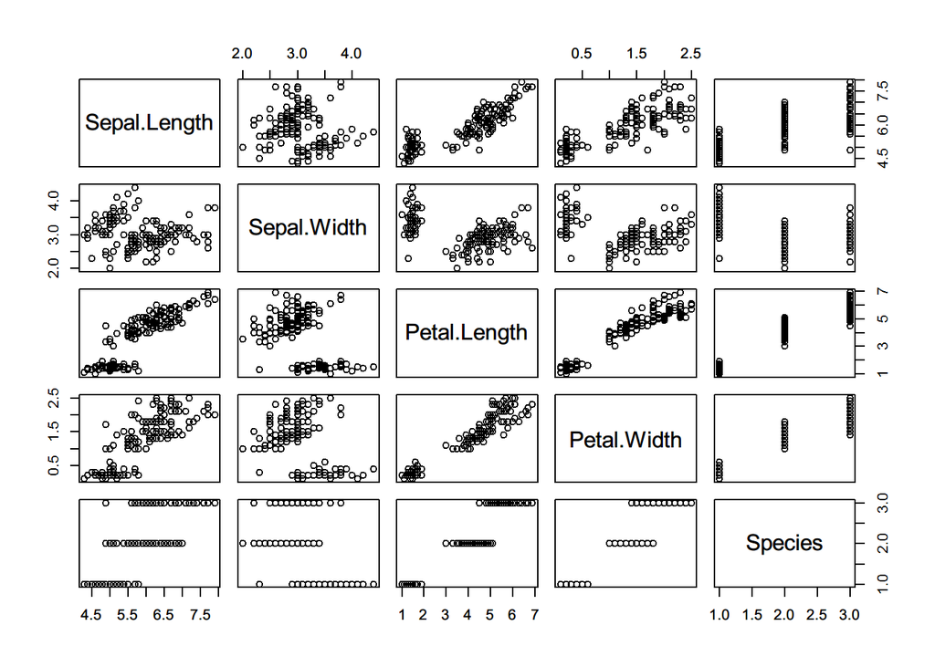

```r
plot(iris)
```